# Cook County Electricity Demand Time Series Modeling - SARIMAX+Fourier

```r
library(forecast)
library(readr)
library(tseries)
library(ggplot2)
library(dplyr)
library(lubridate)
library(future.apply)
Sys.setlocale("LC_ALL", "en_US.UTF-8")
```

```
## [1] "LC_COLLATE=en_US.UTF-8;LC_CTYPE=en_US.UTF-8;LC_MONETARY=en_US.UTF-8;LC_NUMERIC=C;LC_TIME=en_US.UTF-8"
```

```r
# load data
df_1819 <- readRDS("data/train_test_split/df_1819.rds")
df_1819 <- df_1819[-1, ]
df_20   <- readRDS("data/train_test_split/df_20.rds")

cutoff <- ymd_hms("2020-01-01 00:00:00", tz="UTC")
```

### Covariate: Weather

```r
weather_path <- "data/raw/ORD_weather.csv"

df_weather <- read.csv(weather_path, stringsAsFactors = FALSE) %>%
  filter(valid != "valid") %>%
  mutate(
    timestamp = ymd_hm(valid, tz = "UTC"),
    tmpf = parse_number(tmpf),
    dwpf = parse_number(dwpf),
    sped = parse_number(sped),
    p01m = parse_number(p01m),
    ts_hour_utc = round_date(timestamp, "hour")
  )
head(df_weather,2)
```

```
##   station         valid tmpf dwpf  sped p01m           timestamp
## 1     ORD 2018/1/1 0:51    5   -6 12.65    0 2018-01-01 00:51:00
## 2     ORD 2018/1/1 1:51    4   -7 10.35    0 2018-01-01 01:51:00
##           ts_hour_utc
## 1 2018-01-01 01:00:00
## 2 2018-01-01 02:00:00
```

- station: air monitoring station.
- valid: utc timestamp as string
- tmpf: air temperature [F]
- dwpf: dew point [F], the temperature to which air must be cooled to become saturated with water vapor ( relative humidity)
- sped: wind speed [mph]
- p01m: 1 hour precipitation [mm]

**tidy up the weaather df to be aligned with elec demand df**

```r
# round to hour
df_weather_hr <- df_weather %>%
  group_by(ts_hour_utc) %>%
  summarise(
    across(c(tmpf, dwpf, sped, p01m),
           ~ mean(.x, na.rm = TRUE)),
    .groups = "drop"
  ) %>%
  arrange(ts_hour_utc)

# A complete hourly UTC time grid
full_hours <- tibble(
  ts_hour_utc = seq(min(df_weather_hr$ts_hour_utc),
                    max(df_weather_hr$ts_hour_utc),
                    by = "hour")
)

df_weather_full <- full_hours %>%
  left_join(df_weather_hr, by = "ts_hour_utc")

# Missing weather are linearly interpolated.
df_weather_full <- df_weather_full %>%
  arrange(ts_hour_utc) %>%
  mutate(t = as.numeric(ts_hour_utc)) %>%
  mutate(
    across(
      c(tmpf, dwpf, sped, p01m),
      ~ approx(t[!is.na(.x)],
               .x[!is.na(.x)],
               t,
               rule = 2)$y
    )
  ) %>%
  select(-t)
```

**Feature engineering on weather data**

```r
tmp_threshold <-50

df_weather_full <- df_weather_full %>%
  mutate(
    # time
    month = month(ts_hour_utc),

    # Heating Degree Hour & Cooling Degree Hour
    tmpf2 = (tmpf - tmp_threshold)^2,
    HDH   = pmax(tmp_threshold - tmpf, 0),
    HDH2  = HDH^2,
    CDH   = pmax(tmpf - tmp_threshold, 0),
    CDH2  = CDH^2,

    # season indicator
    is_winter = ifelse(month %in% c(12,1,2,3), 1, 0),
    is_summer = ifelse(month %in% c(6,7,8,9), 1, 0),

    # interaction
    winter_HDH  = HDH * is_winter,
    winter_wind = sped * is_winter,
    summer_CDH  = CDH * is_summer,
    summer_dew  = dwpf * is_summer
  )
```

### Fourier

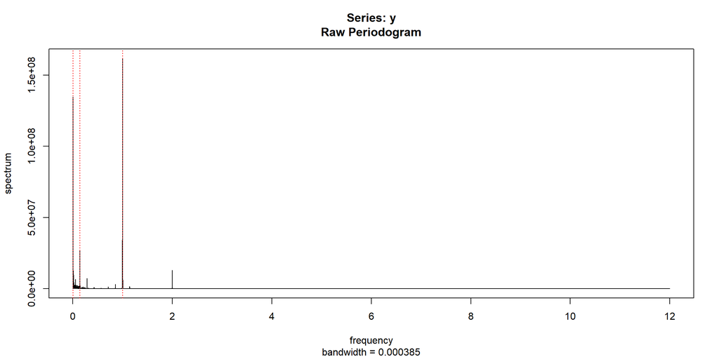

```r
y <- ts(df_1819$electricity_demand, frequency = 24)
sp <- spec.pgram(y, taper=0.1, detrend=TRUE, log="no", plot=TRUE)

abline(v = c(1, 1/7, 1/365), lty = 3, col = "red")  # daily, weekly, annual (cycles/day)
```

The x-axis frequency is cycles per day here. We can see splikes at f = 1 = Daily seasonality, f = 1/7 = Weekly seasonality, f = 1/365 ≈ 0.00274 = Annual seasonality, f ≈ 2 = 12-hour harmonic.

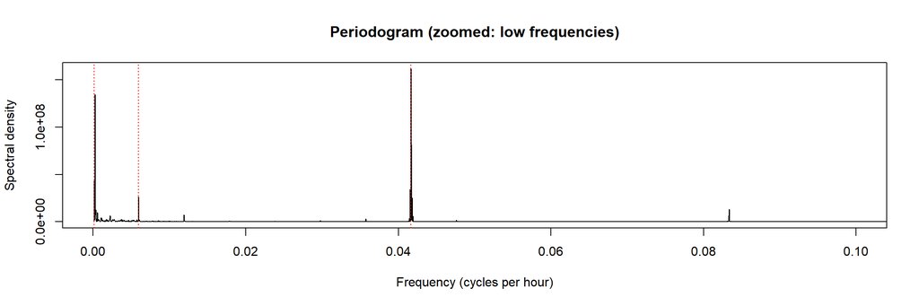

```r
sp <- spec.pgram(y, taper=0.1, detrend=TRUE, plot=FALSE)
plot(sp$freq/24, sp$spec, type="l", xlim=c(0, 1/10),
     xlab="Frequency (cycles per hour)", ylab="Spectral density",
     main="Periodogram (zoomed: low frequencies)")
abline(v=c(1/24,1/168,1/8760), lty=3, col="red")
```

For the x-axis, frequency is divided by 24 to show seasonsality in an hourly way. spikes occur ot 1/24 and 1/168, indicating daily and weekly seasonality, while the spike at 1/12 is daily 2nd harmonic. There is also a strong low-frequency structure. might be trend and annual.

```r
sp <- spec.pgram(y, taper=0.1, detrend=TRUE, plot=FALSE)

# convert to cycles/hour
freq_hour <- sp$freq / 24
spec_val  <- sp$spec

# Top 10 spike
idx <- order(spec_val, decreasing = TRUE)[1:15]

data.frame(
  freq_cycles_per_hour = freq_hour[idx],
  period_hours = 1 / freq_hour[idx],
  spectral_density = spec_val[idx]
)
```

```
##    freq_cycles_per_hour period_hours spectral_density
## 1          0.0416666667     24.00000        161839905
## 2          0.0002222222   4500.00000        134514363
## 3          0.0001111111   9000.00000         43272394
## 4          0.0415555556     24.06417         34263231
## 5          0.0059444444    168.22430         26407692
## 6          0.0417777778     23.93617         25522403
## 7          0.0833333333     12.00000         12983429
## 8          0.0003333333   3000.00000         12809780
## 9          0.0005555556   1800.00000          9769077
## 10         0.0118888889     84.11215          7239232
## 11         0.0002777778   3600.00000          7165361
## 12         0.0022222222    450.00000          6546979
## 13         0.0418888889     23.87268          6160763
## 14         0.0010555556    947.36842          4303027
## 15         0.0010000000   1000.00000          3853639
```

Spike at 84h is weekly harmonic. “Annual” might be mixed in the low frequencies.

### Final Xreg

```r
df_xreg <- df_weather_full %>%
    select(ts_hour_utc, tmpf2, HDH, CDH,winter_HDH,winter_wind, summer_CDH,p01m) %>%
    rename(timestamp = ts_hour_utc)

df_xreg_1819 <- df_xreg %>% filter(timestamp < cutoff)
df_xreg_20   <- df_xreg %>% filter(timestamp >= cutoff)
```

## Train - Validation - Test

### split train validation on 1819 data

```r
H_val <- 24 * 7 * 2  # 2 weeks

# 1) assure time sorting
df_1819      <- df_1819 %>% arrange(timestamp)
df_xreg_1819 <- df_xreg_1819 %>% arrange(timestamp)

# 2) Alignment check
stopifnot(nrow(df_1819) == nrow(df_xreg_1819))
stopifnot(all(df_1819$timestamp == df_xreg_1819$timestamp))

# 3) train/val index
n_1819 <- nrow(df_1819)
idx_train <- 1:(n_1819 - H_val)
idx_val   <- (n_1819 - H_val + 1):n_1819

y_train <- df_1819[idx_train, ]
y_val   <- df_1819[idx_val, ]

df_xreg_train <- df_xreg_1819[idx_train, ]
df_xreg_val   <- df_xreg_1819[idx_val, ]
```

**SARIMAX input dtype：ts + xreg matrix**

```r
y_col <- "electricity_demand"

# ts: hourly, frequency=24
y_train_msts <- msts(y_train[[y_col]], seasonal.periods = c(24, 168))
y_val_msts   <- msts(y_val[[y_col]]  , seasonal.periods = c(24, 168))
y_train_ts   <- ts(y_train[[y_col]], frequency = 24)
y_val_ts     <- ts(y_val[[y_col]]  , frequency = 24)

# xreg: drop timestamp, as.matrix
xreg_train <- df_xreg_train %>% select(-timestamp) %>% as.matrix()
xreg_val   <- df_xreg_val   %>% select(-timestamp) %>% as.matrix()

stopifnot(length(y_train_ts) == nrow(xreg_train))
stopifnot(length(y_val_ts)   == nrow(xreg_val))
stopifnot(ncol(xreg_train)   == ncol(xreg_val))
stopifnot(all(colnames(xreg_train) == colnames(xreg_val)))
```

### Assumptions made for the modeling

(S)ARIMAX models require future values of exogenous covariates when generating forecasts. In this application, weather features such as temperature and precipitation are used as an external regressor. Since reliable weather forecasts are available and generally highly accurate over short horizons, we assume that future temperature forecasts are equal to the realized temperature values. Therefore, weather features are treated as known when producing demand forecasts.

We assume the covariate can solve the heteroscedasticity issue.

The weather data is actually the records from ord station in Chicago, here we assume the weather condition in Chicago and Cook County are identical.

### Train - Validation

#### Create func for validation

```r
plot_residual_diag <- function(fit, timestamp) {
  res <- residuals(fit)
  par(mfrow = c(2,2), mar = c(4,4,2,1))
  plot(timestamp, res, type="l"); abline(h=0,lty=2)
  hist(res, breaks=50, prob=TRUE); lines(density(res, na.rm=TRUE))
  acf(res, lag.max=24, na.action=na.pass, ylim=c(-0.2,0.2))
  pacf(res, lag.max=24, na.action=na.pass)
  par(mfrow=c(1,1))
}

plot_residual_acf_longlag <- function(fit,ylim) {
  res <- residuals(fit)
  par(mfrow=c(2,1), mar=c(4,4,2,1))
  acf(res, lag.max=24*7*4, na.action=na.pass, ylim=c(-ylim,ylim))
  abline(v=c(7,14,21,28), col="red", lty=3)
  pacf(res, lag.max=24*7*4, na.action=na.pass)
  abline(v=c(7,14,21,28), col="red", lty=3)
  par(mfrow=c(1,1))
}
```

```r
calc_metrics <- function(actual, forecast_mean) {
  actual <- as.numeric(actual)
  forecast_mean <- as.numeric(forecast_mean)

  c(
    RMSE = sqrt(mean((actual - forecast_mean)^2)),
    MAE  = mean(abs(actual - forecast_mean)),
    MAPE = mean(abs((actual - forecast_mean) / actual)) * 100
  )
}

plot_train_valid_forecast <- function(
  y_train,           # data.frame, must contain timestamp
  y_train_ts,        # ts or numeric (train actual values)
  y_val,             # data.frame, must contain timestamp
  y_val_ts,          # ts or numeric (validation actual values)
  fc_obj,            # forecast object from forecast()
  ci_level = 2,      # which column of lower/upper to use (e.g., 2 for 95%)
  lookback_days = 7*12  # how many days before split to show
) {
  # --- forecast & actual vector ---
  yhat_valid <- as.numeric(fc_obj$mean)
  y_valid_vec <- as.numeric(y_val_ts)

  # --- align length (safety) ---
  h <- length(yhat_valid)

  # timestamps for validation/forecast must be length h
  ts_val <- y_val$timestamp[seq_len(h)]

  # --- 1. train actual ---
  train_df <- data.frame(
    timestamp = y_train$timestamp,
    value     = as.numeric(y_train_ts),
    type      = "Train"
  )

  # --- 2. validation actual (aligned) ---
  valid_df <- data.frame(
    timestamp = ts_val,
    value     = y_valid_vec[seq_len(h)],
    type      = "Validation"
  )

  # --- 3. forecast df (aligned) ---
  forecast_df <- data.frame(
    timestamp = ts_val,
    Forecast  = yhat_valid,
    Lower     = fc_obj$lower[seq_len(h), ci_level],
    Upper     = fc_obj$upper[seq_len(h), ci_level]
  )

  split_time <- min(ts_val)

  # --- 4. plot ---
  ggplot2::ggplot() +
    ggplot2::geom_line(
      data = train_df,
      ggplot2::aes(x = timestamp, y = value),
      color = "black", linewidth = 0.6
    ) +
    ggplot2::geom_line(
      data = valid_df,
      ggplot2::aes(x = timestamp, y = value),
      color = "black", linewidth = 0.6
    ) +
    ggplot2::geom_ribbon(
      data = forecast_df,
      ggplot2::aes(x = timestamp, ymin = Lower, ymax = Upper),
      fill = "pink", alpha = 0.3
    ) +
    ggplot2::geom_line(
      data = forecast_df,
      ggplot2::aes(x = timestamp, y = Forecast),
      color = "red", linewidth = 0.7
    ) +
    ggplot2::geom_vline(
      xintercept = split_time,
      linetype = "dashed", color = "blue"
    ) +
    ggplot2::theme_minimal() +
    ggplot2::labs(
      title = "Train + Validation Forecast",
      x = "Time",
      y = "Electricity Demand"
    ) +
    ggplot2::coord_cartesian(
      xlim = c(
        split_time - lubridate::days(lookback_days),
        max(ts_val)
      )
    )
}
```

#### Try 1

```r
weather_vars_subset1 <- c("winter_HDH","winter_wind", "summer_CDH","p01m")
Xreg_input <- xreg_train[, weather_vars_subset1, drop = FALSE]

K1 <- c(12, 6)
X_fourier <- fourier(y_train_msts, K=K1)

fit_arimax_fourier_1 <- auto.arima(
  y_train_msts,
  xreg = cbind(Xreg_input,X_fourier),
  seasonal = FALSE
)

summary(fit_arimax_fourier_1)
```

```
## Series: y_train_msts
## Regression with ARIMA(5,1,1) errors
##
## Coefficients:
##          ar1      ar2     ar3     ar4      ar5      ma1  winter_HDH
##       1.7177  -1.0332  0.3396  0.0050  -0.1395  -0.9028      7.9588
## s.e.  0.0087   0.0159  0.0172  0.0154   0.0079   0.0041      0.8577
##       winter_wind  summer_CDH    p01m      S1-24     C1-24     S2-24    C2-24
##           -0.2238      8.1533  2.8671  -664.5568  657.2897  278.6452  59.1993
## s.e.       0.2940      0.5941  0.7492    21.0094   20.9993    3.7321   3.7370
##         S3-24     C3-24    S4-24     C4-24     S5-24    C5-24   S6-24   C6-24
##       -1.8572  -13.9754  37.8014  -13.2028  -23.5345  -9.0067  0.5516  7.7445
## s.e.   1.7903    1.7902   1.3170    1.3166    1.0821   1.0822  0.7526  0.7525
##         S7-24   C7-24   S8-24   C8-24    S9-24   C9-24   S10-24  C10-24
##       -9.2637  4.1942  1.1021  0.7456  -1.0554  1.9118  -0.6920  0.2762
## s.e.   0.4877  0.4877  0.3482  0.3482   0.2808  0.2808   0.2503  0.2503
##        S11-24  C11-24   C12-24    S1-168     C1-168    S2-168     C2-168
##       -0.9604  0.3559  -0.3045  251.0398  -318.7406  172.3746  -113.4894
## s.e.   0.2386  0.2387   0.1669   24.9954    24.9881   15.3485    15.3422
##        S3-168    C3-168   S4-168    C4-168   S5-168    C5-168   S6-168
##       84.4443  -27.6838  17.9998  -62.5587  32.4309  -88.5051  82.3330
## s.e.  13.4685   13.4666  13.8783   13.8753  15.8117   15.8091  19.0155
##          C6-168
##       -104.3562
## s.e.    19.0162
##
## sigma^2 = 8254:  log likelihood = -101836.1
## AIC=203764.2   AICc=203764.5   BIC=204120.8
##
## Training set error measures:
##                       ME     RMSE      MAE         MPE      MAPE       MASE
## Training set -0.05258864 90.72966 64.31089 -0.00908094 0.9661748 0.09985065
##                      ACF1
## Training set -0.007284378
```

**Check Residuals**

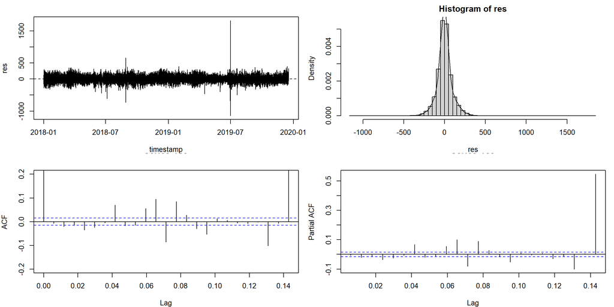

```r
plot_residual_diag(fit_arimax_fourier_1, y_train$timestamp)
```

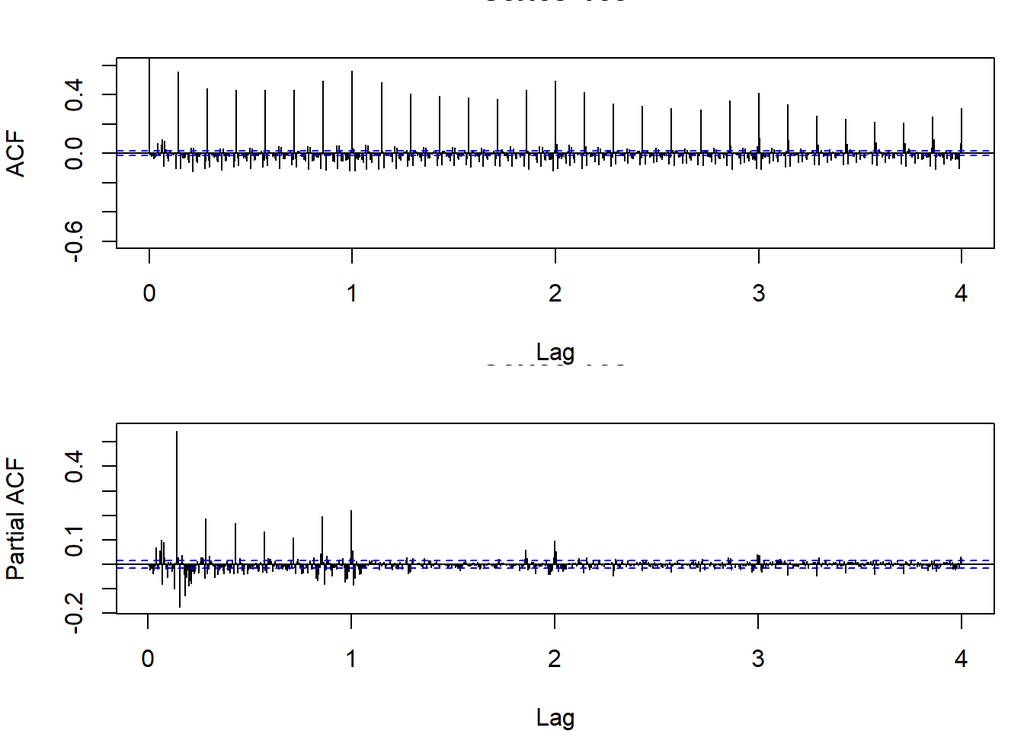

```r
plot_residual_acf_longlag(fit_arimax_fourier_1,ylim=0.6)
```

Obiviously that, acf and pacf all have significant weekly lags, indicating that seasonality = 168 should be considered.

This shows the limitation of SARIMAX can only have one seasonality.

**Validation**

```r
weather_vars <- weather_vars_subset1
xreg_val_subset <- xreg_val[, weather_vars, drop = FALSE]

X_fourier_val <- fourier(y_train_msts, K = K1, h = H_val)
X_val_all <- cbind(xreg_val_subset, X_fourier_val)

fc_arimax_fourier_1 <- forecast(fit_arimax_fourier_1, h = H_val, xreg = X_val_all)
```

```r
calc_metrics(y_val_ts, fc_arimax_fourier_1$mean)
```

```
##      RMSE       MAE      MAPE
## 992.06169 801.36506  14.08353
```

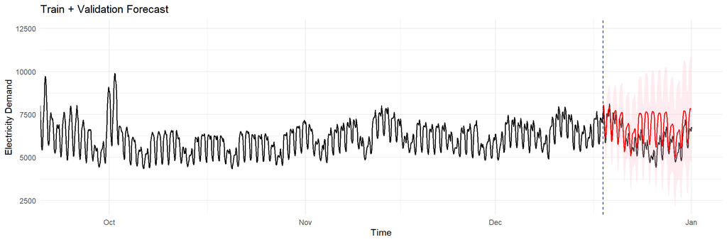

```r
plot_train_valid_forecast(
  y_train = y_train,
  y_train_ts = y_train_ts,
  y_val = y_val,
  y_val_ts = y_val_ts,
  fc_obj = fc_arimax_fourier_1,
  ci_level = 2,
  lookback_days = 7*12
)
```

#### Try 2: SARIMA(…)[24] + weekly Fourier

```r
# auto.arima -> (3,0,1)(3,1,2)[24] with "tmpf2"
weather_vars_subset2 <- c("winter_HDH", "summer_CDH","p01m")

K_week <- 3
X_week_fourier_train <- fourier(y_train_msts, K = c(0, K_week))
Xreg_input <- cbind(xreg_train[, weather_vars_subset2, drop=FALSE], X_week_fourier_train)

fit_sarimax_D1_weekF_1 <- Arima(
  y_train_ts,
  xreg = Xreg_input,
  order = c(3,0,1),
  seasonal = list(order = c(2,1,1), period = 24),
  method = "CSS-ML",
)

summary(fit_sarimax_D1_weekF_1)
```

```
## Series: y_train_ts
## Regression with ARIMA(3,0,1)(2,1,1)[24] errors
##
## Coefficients:
##          ar1      ar2     ar3      ma1    sar1     sar2     sma1  winter_HDH
##       2.0223  -1.3327  0.2951  -0.2161  0.1863  -0.0876  -0.8367      2.8156
## s.e.  0.0512   0.0868  0.0369   0.0531  0.0090   0.0084   0.0048      0.6259
##       summer_CDH    p01m    S1-168     C1-168    S2-168     C2-168   S3-168
##           5.6319  3.7455  243.7909  -328.8843  176.6513  -105.1100  88.9413
## s.e.      0.4233  0.5181   35.1341    35.1416   23.3767    23.3753  14.3339
##         C3-168
##       -32.8706
## s.e.   14.3291
##
## sigma^2 = 4483:  log likelihood = -96491.18
## AIC=193016.4   AICc=193016.4   BIC=193148.1
##
## Training set error measures:
##                      ME     RMSE      MAE         MPE      MAPE       MASE
## Training set -0.1041749 66.87656 45.45935 -0.01082659 0.6933242 0.09312237
##                       ACF1
## Training set -0.0008024208
```

**Check Residuals**

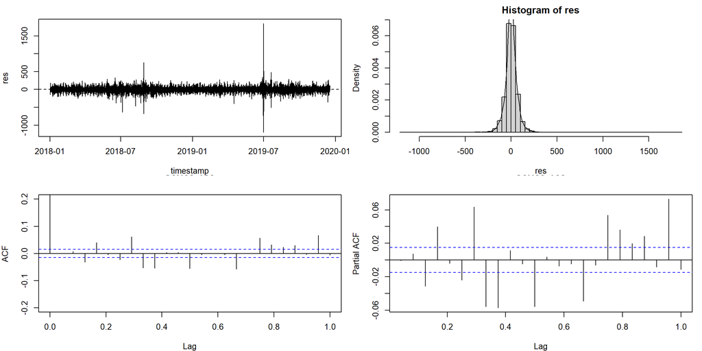

```r
plot_residual_diag(fit_sarimax_D1_weekF_1, y_train$timestamp)
```

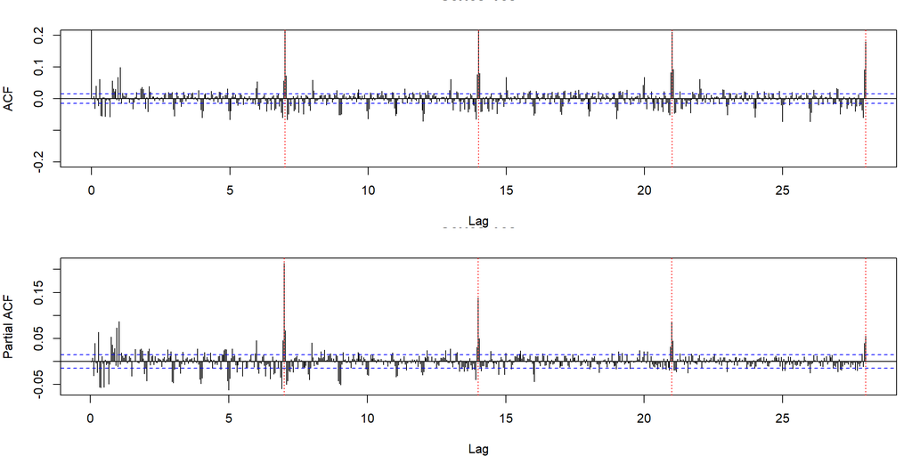

```r
plot_residual_acf_longlag(fit_sarimax_D1_weekF_1,0.2)
```

**Validation**

```r
weather_vars <- weather_vars_subset2

X_week_fourier_val <- fourier(y_train_msts, K = c(0, K_week), h = H_val)

xreg_val_input <- cbind(
  xreg_val[, weather_vars, drop = FALSE],
  X_week_fourier_val
)

fc_sarimax_D1_weekF_1 <- forecast(fit_sarimax_D1_weekF_1, h = H_val, xreg = xreg_val_input)
```

```r
calc_metrics(y_val_ts, fc_sarimax_D1_weekF_1$mean)
```

```
##      RMSE       MAE      MAPE
## 843.79010 660.32909  11.84533
```

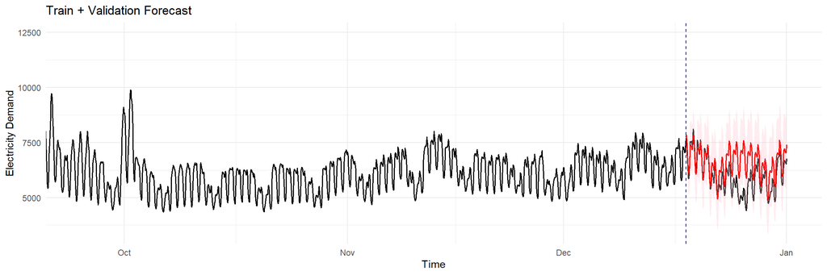

```r
plot_train_valid_forecast(
  y_train = y_train,
  y_train_ts = y_train_ts,
  y_val = y_val,
  y_val_ts = y_val_ts,
  fc_obj = fc_sarimax_D1_weekF_1,
  ci_level = 2,
  lookback_days = 7*12
)
```

#### Try 3: SARIMA(…)[24] + weekly Fourier K = 5

```r
# auto.arima -> (3,0,1)(3,1,2)[24] with "tmpf2"
weather_vars_subset2 <- c("winter_HDH", "summer_CDH","p01m")

K_week2 <- 5
X_week_fourier_train <- fourier(y_train_msts, K = c(0, K_week2))
Xreg_input <- cbind(xreg_train[, weather_vars_subset2, drop=FALSE], X_week_fourier_train)

fit_sarimax_D1_weekF_2 <- Arima(
  y_train_ts,
  xreg = Xreg_input,
  order = c(3,0,1),
  seasonal = list(order = c(2,1,1), period = 24),
  method = "CSS-ML",
)

summary(fit_sarimax_D1_weekF_2)
```

```
## Series: y_train_ts
## Regression with ARIMA(3,0,1)(2,1,1)[24] errors
##
## Coefficients:
##          ar1      ar2     ar3      ma1    sar1     sar2     sma1  winter_HDH
##       2.0668  -1.4143  0.3335  -0.2684  0.1912  -0.0858  -0.8376      2.8231
## s.e.  0.0541   0.0911  0.0383   0.0568  0.0090   0.0084   0.0048      0.6256
##       summer_CDH    p01m    S1-168     C1-168    S2-168     C2-168   S3-168
##           5.6661  3.7475  243.8713  -329.2886  175.0977  -105.4564  89.0571
## s.e.      0.4238  0.5180   35.0911    35.1013   22.5859    22.5894  13.6913
##         C3-168   S4-168    C4-168   S5-168    C5-168
##       -32.1982  15.4808  -58.1004  35.1988  -91.1375
## s.e.   13.6865  10.7706   10.7708  10.9484   10.9455
##
## sigma^2 = 4457:  log likelihood = -96440.04
## AIC=192922.1   AICc=192922.1   BIC=193084.8
##
## Training set error measures:
##                      ME     RMSE      MAE        MPE      MAPE       MASE
## Training set -0.1029584 66.67801 45.40097 -0.0102434 0.6916645 0.09300279
##                      ACF1
## Training set 0.0002935608
```

**Check Residuals**

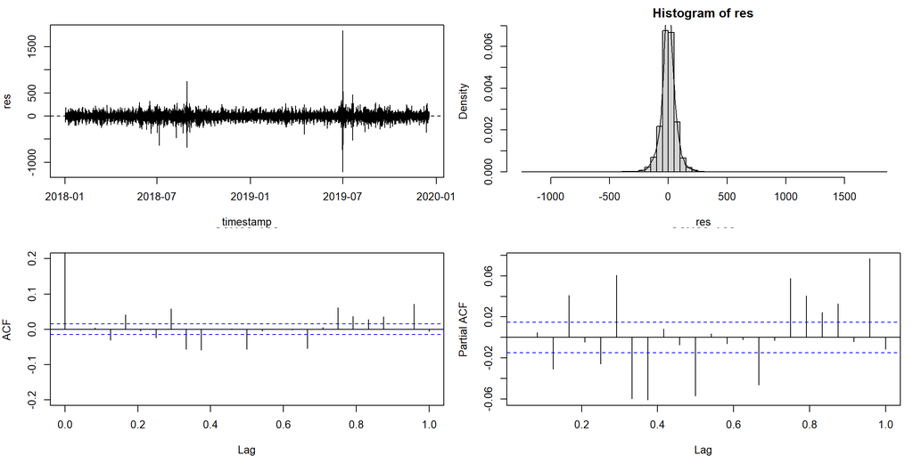

```r
plot_residual_diag(fit_sarimax_D1_weekF_2, y_train$timestamp)
```

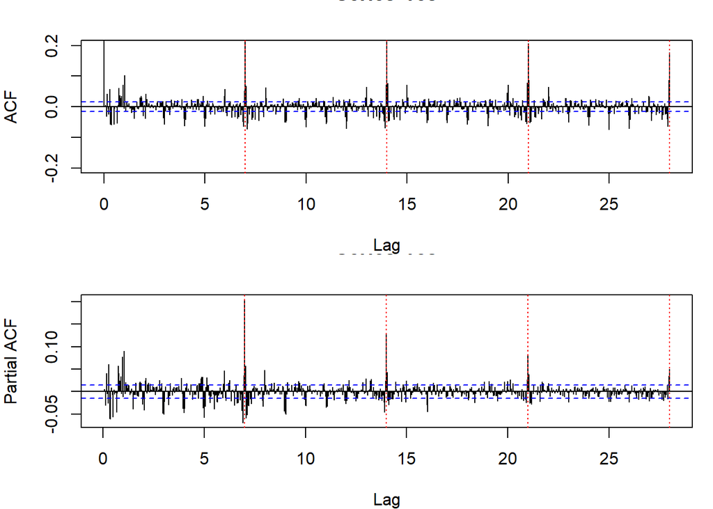

```r
plot_residual_acf_longlag(fit_sarimax_D1_weekF_2,0.2)
```

**Validation**

```r
weather_vars <- weather_vars_subset2

X_week_fourier_val <- fourier(y_train_msts, K = c(0, K_week2), h = H_val)

xreg_val_input <- cbind(
  xreg_val[, weather_vars, drop = FALSE],
  X_week_fourier_val
)

fc_sarimax_D1_weekF_2 <- forecast(fit_sarimax_D1_weekF_2, h = H_val, xreg = xreg_val_input)
```

```r
calc_metrics(y_val_ts, fc_sarimax_D1_weekF_2$mean)
```

```
##      RMSE       MAE      MAPE
## 836.39760 655.09035  11.72461
```

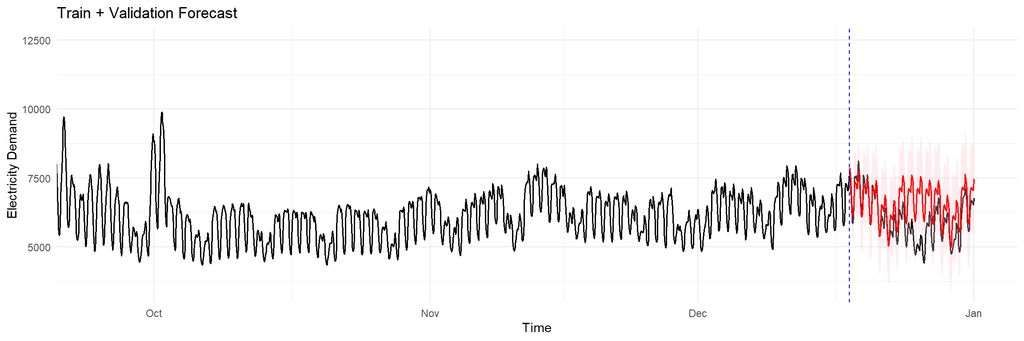

```r
plot_train_valid_forecast(
  y_train = y_train,
  y_train_ts = y_train_ts,
  y_val = y_val,
  y_val_ts = y_val_ts,
  fc_obj = fc_sarimax_D1_weekF_2,
  ci_level = 2,
  lookback_days = 7*12
)
```

### Forecast output on Test Data

#### Train the model on whole training data

```r
y_1819_ts   <- ts(df_1819$electricity_demand, frequency = 24)
y_1819_msts <- msts(df_1819$electricity_demand, seasonal.periods = c(24,168))


Xreg_1819 <- df_xreg_1819 %>% select(winter_HDH, summer_CDH, p01m) %>% as.matrix()
X_week_fourier_1819 <- fourier(y_1819_msts, K = c(0, 5))
xreg_train <- cbind(Xreg_1819, X_week_fourier_1819)

stopifnot(nrow(xreg_train) == length(y_1819_ts))

final_fit_sarimax_fourier <- Arima(
  y_1819_ts,
  xreg = xreg_train,
  order = c(3,0,1),
  seasonal = list(order = c(2,1,1), period = 24),
  method = "CSS-ML"
)
```

#### Forecast on test

```r
# forecast horizon
h_fc <- 24*7*4

Xreg_test <- df_xreg_20 %>%
  slice(seq_len(h_fc)) %>%
  select(all_of(colnames(Xreg_1819))) %>%
  as.matrix()

X_week_future <- fourier(y_1819_msts, K = c(0, 5), h = h_fc)
xreg_future <- cbind(Xreg_test, X_week_future)

stopifnot(nrow(xreg_future) == h_fc)

fc_test <- forecast(final_fit_sarimax_fourier, h = h_fc, xreg = xreg_future)

forecast_df_test <- data.frame(
  timestamp = df_xreg_20$timestamp[seq_len(h_fc)],
  Forecast  = as.numeric(fc_test$mean),
  Lower     = fc_test$lower[,2],  # 95%
  Upper     = fc_test$upper[,2]
)
```

#### Save forecast results of test data

```r
modeling_method <- "SARIMAX_w_fourier"
forecast_path  <- paste0("data/test_forecast/", modeling_method, "_20Jan.csv")

write.csv(
  forecast_df_test,
  forecast_path,
  row.names = FALSE
)
```